# 01c_introduction_python slides

## Week 1: Introduction to Python

### Python for Social Data Science

### Tom Paskhalis

## Overview

- Backstory
- Jupyter Notebook
- Markdown
- Operators

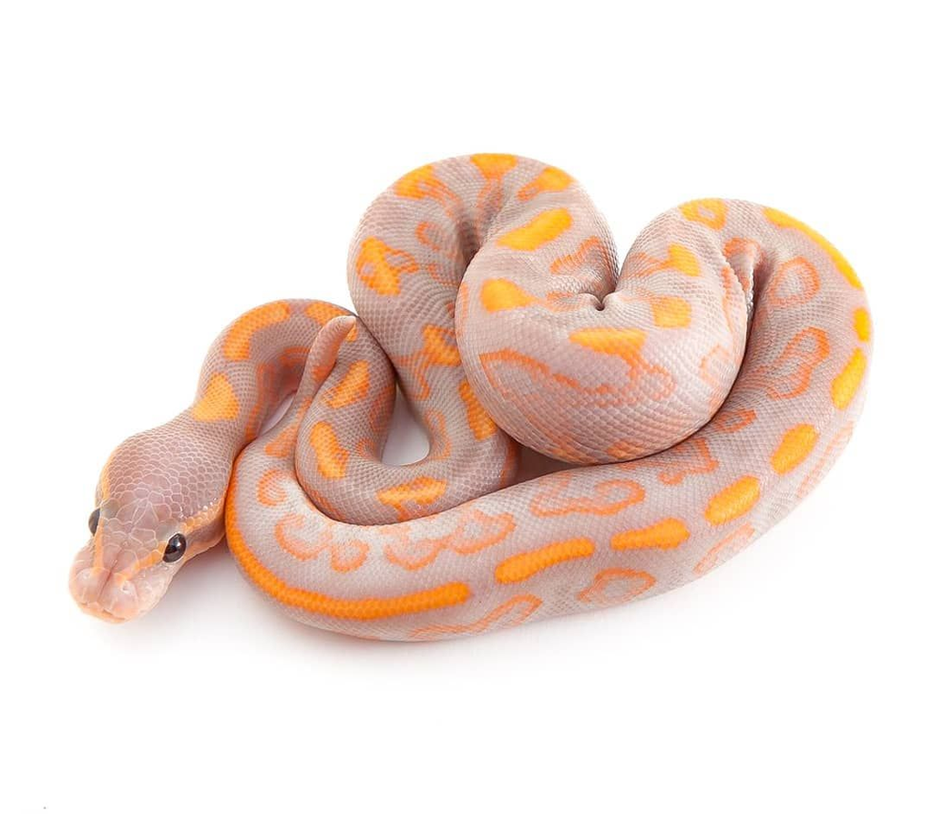

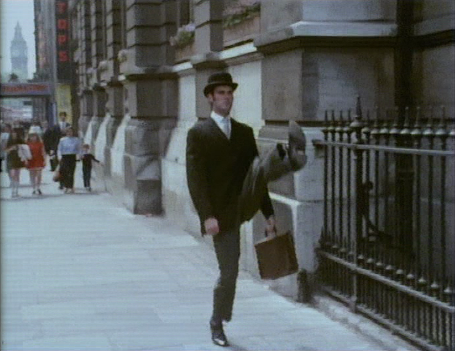

## R/Stata/SPSS is great, why learn Python?

- [Python is free and open source](https://github.com/python/cpython)
- [Python is a truly versatile programming language](https://github.com/readme/nasa-ingenuity-helicopter)
- [Python offers a great library ecosystem (>300K)](https://pypi.org/)
- [Python is widely used in the industry](https://www.tiobe.com/tiobe-index/)
- [Python is well-known outside academia/data science](https://www.economist.com/science-and-technology/2018/07/19/python-has-brought-computer-programming-to-a-vast-new-audience)

## Popularity of programming languages

[figure not shown]

Source: [TIOBE](https://www.tiobe.com/tiobe-index/)

## Popularity of data analysis software

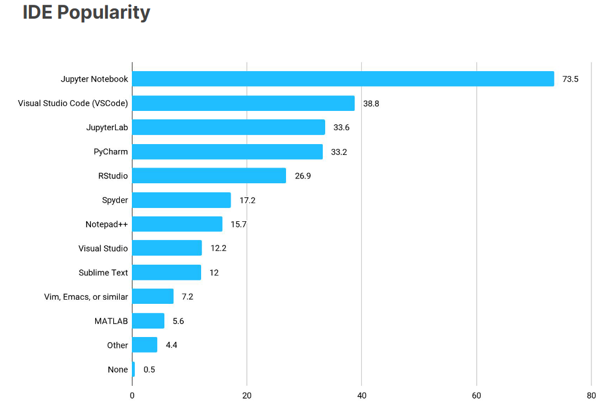

Source: [Kaggle 2021 *State of Data Science and Machine Learning* survey](https://www.kaggle.com/kaggle-survey-2021)

## Python and Development Enviroments

- There is a number of integrated development environments (*IDE*s) available for Python (IDLE, Spyder, PyCharm)
- As well code editors with Python-specific extensions (Visual Studio Code, Atom, Sublime Text, Vim)
- Try different ones and choose what works best for you!

## Python and Jupyter Notebook

- [Jupyter Notebook](https://jupyter-notebook.readthedocs.io/en/latest/) is language-agnostic web-based interactive computational environment
- Is available with backends (*kernels*) for different programming languages (**Ju**lia, **Py**thon, **R** = **Jupy**te**r**)
- Can be used both locally and remotely
- Good for ad-hoc data analysis and visualization

## Jupyter Notebook Installation

- There are two main ways to install Jupyter Notebook locally: pip and conda. Unless you have prior experience with Python, I recommend installing [Anaconda](https://www.anaconda.com/products/individual) distribution, which contains all the packages required for this course.
- Alternatively, you may choose to use [Kaggle Code](https://www.kaggle.com/code) or [Google Colab](https://colab.research.google.com/notebooks/intro.ipynb), online platforms for hosting Jupyter Notebooks. Their interfaces are slightly different and you need to register on Kaggle or have a Google account, but it does not require any local installations.
- However, for this module and course more broadly I recommend installing toolchaing for working with Jupyter Notebooks locally.

## Starting Jupyter

- To start Jupyter, open CLI/Terminal and type `jupyter notebook`
- This will open a browser window with Jupyter Notebook displaying the directory, in which you executed the command above.
- To create a new notebook press `New` and select `Python` from the drop-down menu

## Using Jupyter

- In order to run a Python command, create a new cell:
  - Press ➕ in the toolbar or click `Insert`, `Insert Cell Below`
  - Make sure that in the drop-down menu on the toolbar you select `Code`
  - Press CTRL+ENTER to run a command
- Rather than running a Python command, you can also write Markdown in the cell (e.g. to create slides)
  - Select `Markdown` in the drop-down manu on the toolbar
  - Write Markdown (check [Markdown Cheatsheet](https://enterprise.github.com/downloads/en/markdown-cheatsheet.pdf))
  - Press CTRL+ENTER to render Markdown cell

## Jupyter Notebook Demonstration

[figure not shown]

## Jupyter Notebook Demonstration

[figure not shown]

## Stopping Jupyter Notebook

- First, make sure you saved your work (!) by pressing Command+S / CTRL+S
- You can close the running notebook by clicking `File` and then `Close and Halt`
- Jupyter Notebook runs as a server
- Which means that closing its tabs/web browser does not stop it
- You need to press `Quit` in the upper right corner of your main Jupyter tab (located at `http://localhost:8888/`)
- Alternatively, you can press CTRL+C in the terminal window

## Python background

- Started as a side-project in 1989 by Guido van Rossum, BDFL (benevolent dictator for life) until 2018.
- Python 3, first released in 2008, is the current major version
- Python 2 support stopped on 1 January 2020

## The Zen of Python

```python
import this
```

```
The Zen of Python, by Tim Peters

Beautiful is better than ugly.
Explicit is better than implicit.
Simple is better than complex.
Complex is better than complicated.
Flat is better than nested.
Sparse is better than dense.
Readability counts.
Special cases aren't special enough to break the rules.
Although practicality beats purity.
Errors should never pass silently.
Unless explicitly silenced.
In the face of ambiguity, refuse the temptation to guess.
There should be one-- and preferably only one --obvious way to do it.
Although that way may not be obvious at first unless you're Dutch.
Now is better than never.
Although never is often better than *right* now.
If the implementation is hard to explain, it's a bad idea.
If the implementation is easy to explain, it may be a good idea.
Namespaces are one honking great idea -- let's do more of those!
```

## Python basics

- Python is an *interpreted* language (like R and Stata)
- Every program is executed one *command* (aka *statement*) at a time
- Which also means that work can be done interactively

```python
print("Hello World!")
```

```
Hello World!
```

## Python conceptual hierarchy

Python programs can be decomposed into modules, statements, expressions, and objects, as follows:

1. **Programs** are composed of **modules**.
2. **Modules** contain **statements**.
3. **Statements** contain **expressions**.
4. **Expressions** create and process **objects**.

## Python objects

- Everything that Python operates on is an **object**.
- This includes numbers, strings, data structures, functions, etc.
- Eact object has a **type** (e.g. string or function) and internal **data**.
- Objects can be **mutable** (e.g. list) and **immutable** (e.g. string).

## Operators

*Objects* and *operators* are combined to form *expressions*. Key *operators* are:

- Arithmetic (`+`, `-`, `*`, `**`, `/`, `//`, `%`)
- Boolean (`and`, `or`, `not`)
- Relational (`==`, `!=`, `>`, `>=`, `<`, `<=`)
- Assignment (`=`, `+=`, `-=`, `*=`, `/=`)
- Membership (`in`)

## Basic mathematical operations in Python

```python
1 + 1
```

```
2
```

```python
5 - 3
```

```
2
```

```python
6 / 2
```

```
3.0
```

```python
4 * 4
```

```
16
```

```python
# Exponentiation <- Python comments start with #
2 ** 4
```

```
16
```

## Advanced mathematical operations in Python

```python
# Integer division (remainder is discarded)
7 // 3
```

```
2
```

```python
# Modulo operation (only remainder is retained)
7 % 3
```

```
1
```

## Basic logical operations in Python

```python
3 != 1 # Not equal
```

```
True
```

```python
3 > 3 # Greater than
```

```
False
```

```python
3 >= 3 # Greater than or equal
```

```
True
```

```python
False or True # True if either first or second operand is True, False otherwise
```

```
True
```

```python
3 > 3 or 3 >= 3 # Combining 3 Boolean expressions
```

```
True
```

## Assignment operations

Assignments create object references. *Target* (or *name*) on the left is assigned to *object* on the rigth.

```python
x = 3
```

```python
x
```

```
3
```

```python
x += 2 # Increment assignment, equivalent to x = x + 2
```

```python
x
```

```
5
```

## Assignment vs Comparison Operators

As `=` (assignment) and `==` (equality comparison) operators appear very similar, they sometime can create confusion.

```python
x = 3
```

```python
x
```

```
3
```

```python
x == 3
```

```
True
```

## Membership operations

Operator `in` returns `True` if an object of the left side is in a sequence on the right.

```python
'a' in 'abc'
```

```
True
```

```python
4 in [1, 2, 3] # [1,2,3] is a list
```

```
False
```

```python
4 not in [1, 2, 3]
```

```
True
```

## Markdown formatting basics

- Use `_` or `*` for emphasis (single - italic, double - bold, triple - bold and italic)
  - `*one*` becomes *one*, `__two__` - **two** and `***three***` - ***three***
- Headers or decreasing levels follow `#`, `##`, `###`, `####` and so on
- (Unordered) Lists follow marker `-`, `+` or `*`
  - Start at the left-most position for top-level
  - Indent four space and use another marker for nesting like here
- (Numbered) Lists use `1.` (counter is auto-incremented)
- Links have syntax of `[some text here](url_here)`
- Images similarly: `![alt text](url or path to image)`

## Markdown example

```
Some text in *italic* and **bold**

Simple list:

- A
- B

Ordered list:

1. A
1. B

Formula - $Y = X + 5$
```

## Markdown example

Some text in *italic* and **bold**

Simple list:

- A
- B

Ordered list:

1. A
2. B

Formula - $Y = X + 5$

## Next Week

- Python fundamentals